# Rescaling MI pars

Author

Max Lindmark

Published

2025-03-06

# Intro

Fit models à la Essington (2022) to acquire metabolic index parameters from a mixed GLMM (glmmTMB), leveraging information from species with lots of experimental data. Save metabolic index params and export as csv.

## Load packages & source functions

```r
# Load libraries, install if needed
library(tidyverse)
library(readxl)
library(tidylog)
library(RCurl)
library(devtools)
library(glmmTMB)
library(rMR)
library(RColorBrewer)
library(patchwork)

# Source code for plots

home <- here::here()
```

# Intro

```r
# https://github.com/fate-spatialindicators/SDM_O2/blob/master/code/estimate_mi_parameters.R

# Read data
o2 <- read_delim(paste0(home, "/data/metabolic-index/essington_pO2_extended.csv"), delim = ";") |>
  dplyr::select(-comment)

unique(o2$source)
```

```
[1] "Essington2022" "Lindmark"
```

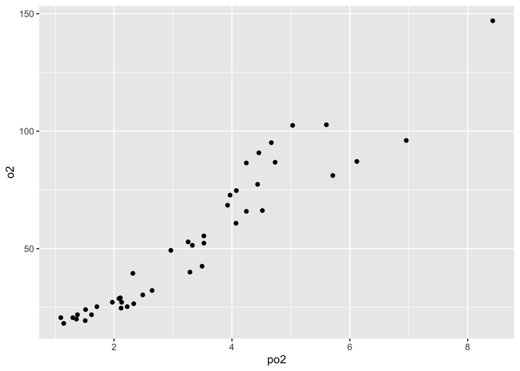

```r
# Now we need to standardize units across experimental data
spc_list <- unique(o2$spc)

c_to_K <- function(x) x + 273.15

# TODO: check salinity units in Essington data, not sure it's correct + my values are in pp.thou
# Get the experimental data in po2
o2$po2 <- NA
for (i in 1:length(spc_list)) {

  spc_index <- which(o2$spc == spc_list[i])

  tmp_dat <- dplyr::filter(o2, spc == spc_list[i])

  tmp_dat$po2 <- DO.unit.convert(tmp_dat$lc50,
                                 DO.units.in = tmp_dat$units[1],
                                 DO.units.out = "PP",
                                 bar.press = 1,
                                 bar.units.in = "atm",
                                 temp.C = tmp_dat$temp,
                                 bar.units.out = "kpa",
                                 salinity = tmp_dat$salinity[1],
                                 salinity.units = "uS")

  o2$po2[spc_index] <- tmp_dat$po2

}

# Get the experimental data in unit mg/L
o2$o2 <- NA

for (i in 1:length(spc_list)) {

  spc_index <- which(o2$spc == spc_list[i])

  tmp_dat <- dplyr::filter(o2, spc == spc_list[i])

  tmp_dat$o2 <- DO.unit.convert(tmp_dat$lc50,
                                DO.units.in = tmp_dat$units[1],
                                DO.units.out = "mg/L",
                                bar.press = 1,
                                bar.units.in = "atm",
                                temp.C = tmp_dat$temp,
                                bar.units.out = "kpa",
                                salinity = tmp_dat$salinity[1],
                                salinity.units = "uS")

  o2$o2[spc_index] <- tmp_dat$o2

}

# Now convert to convert oxygen from mg/L -> ml/L -> micro mol/l
# 1 mg/l = 22.391 ml/31.998 = 0.700 ml/l
# https://www.ices.dk/data/tools/Pages/Unit-conversions.aspx

o2$o2 <- ((o2$o2*0.7) * (10^3)) / 22.391

o2$spc <- as.factor(o2$spc)
nspc <- length(levels(o2$spc))

ggplot(o2, aes(po2, o2)) +
  geom_point()
```

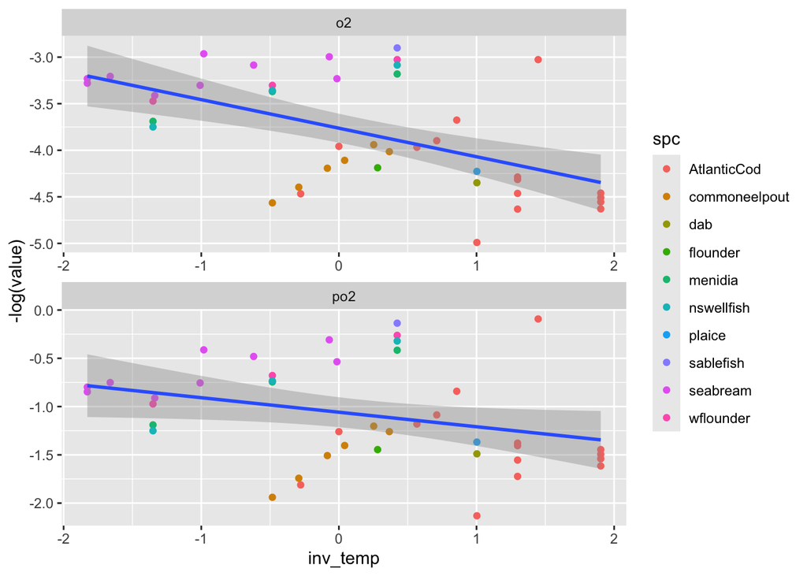

```r
# Add Boltzmann-Arrhenius temperature
tref <- 15 # arbitrary reference temperature
kb <- 0.000086173324 # Boltsmann's constant in unit Ev
o2$inv_temp <- (1 / kb)  * ( 1 / (o2$temp + 273.15) - 1 / (tref + 273.15))

# Plot the data we want to fit
o2 |>
  pivot_longer(c(po2, o2)) |>
  ggplot(aes(inv_temp, -log(value), color = spc)) +
  geom_point() +
  geom_smooth(aes(inv_temp, -log(value)), method = "lm", inherit.aes = FALSE) +
  facet_wrap(~name, ncol = 1, scales = "free")
```

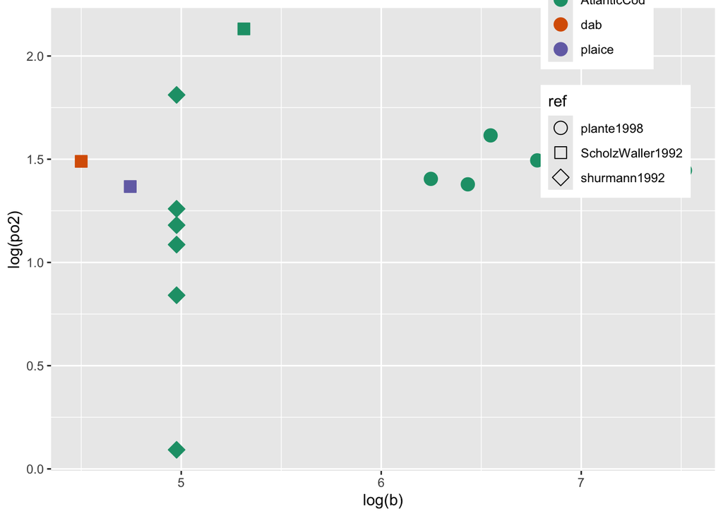

```r
o2 |>
  filter(spc %in% c("AtlanticCod", "plaice", "dab")) |>
  ggplot(aes(log(b), log(po2), shape = ref, fill = spc, color = spc)) +
  geom_point(size = 4) +
  scale_shape_manual(values = c(21:24)) +
  scale_color_brewer(palette = "Dark2") +
  scale_fill_brewer(palette = "Dark2") +
  theme(legend.position = c(0.85, 0.85))
```

The last plot illustrates the issue with cod. We know from regional experiments that Baltic cod have a higher critical oxygen, but if we use experiments by Plante using cod from the Western Atlantic, we will estimate them to be MORE oxygen tolerant than Baltic flatfishes. We don’t have enough data to estimate both a random species intercept and a “reference” effect. So what I’ll do is that I use the original Essington data to estimate the size and temperature dependence of (p)O_2 crit, and then use those estimates to temperature-correct the Baltic experimental data (which anyway don’t have mass or temperature variation, so removing them from the data set is a small loss.)

```r
o2_og <- o2 |>
  filter(source == "Essington2022")

# fe_po2 <- tibble(term = names(fixef(fit_po2)$cond),
#              est = fixef(fit_po2)$cond) |>
#   filter(term %in% c("log(b)", "inv_temp")) |>
#   pivot_wider(names_from = "term", values_from = est) |>
#   rename(n_po2 = `log(b)`,
#          E_po2 = inv_temp)

# oxygen in unit micro mol / L
fit_o2 <- glmmTMB(-log(o2) ~ (1|spc) + log(b) + inv_temp,
                  data = o2_og,
                  family = gaussian(link = "identity"))

summary(fit_o2)
```

```
 Family: gaussian  ( identity )
Formula:          -log(o2) ~ (1 | spc) + log(b) + inv_temp
Data: o2_og

     AIC      BIC   logLik deviance df.resid
    31.7     40.0    -10.8     21.7       34

Random effects:

Conditional model:
 Groups   Name        Variance Std.Dev.
 spc      (Intercept) 0.52522  0.7247
 Residual             0.05191  0.2278
Number of obs: 39, groups:  spc, 7

Dispersion estimate for gaussian family (sigma^2): 0.0519

Conditional model:
            Estimate Std. Error z value Pr(>|z|)
(Intercept) -2.42807    0.35419  -6.855 7.11e-12 ***
log(b)      -0.29977    0.05968  -5.023 5.08e-07 ***
inv_temp     0.29388    0.07402   3.970 7.18e-05 ***
---
Signif. codes:  0 '***' 0.001 '**' 0.01 '*' 0.05 '.' 0.1 ' ' 1
```

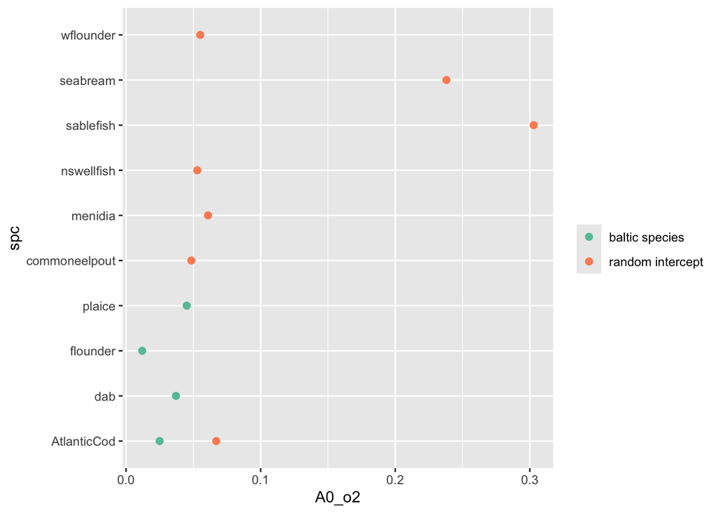

```r
# Extract parameters (fixed)
fe <- tibble(term = names(fixef(fit_o2)$cond),
                est = fixef(fit_o2)$cond) |>
  filter(term %in% c("log(b)", "inv_temp")) |>
  pivot_wider(names_from = "term", values_from = est) |>
  rename(n = `log(b)`,
         E = inv_temp)

# Temperature and mass correct Baltic species critical oxygen using Essington Eq. 2 and the estimated parameters
# Following Essington eq. 2, I can calculate A_oi by rearranged it
# log_po2 = -E*inv_temp - log(Ao) - n*log(b)
# ->
# log(Ao) = -E*inv_temp - n*log(b) - log_po2

# Find A_oi in the new data given fixed effects of temperature and mass, and log(o2_crit)
o2_new <- o2 |>
  filter(source == "Lindmark") |>
  dplyr::select(spc, b, inv_temp, temp, po2, o2)

o2_new <- o2_new |>
  mutate(A0_o2 = exp(-fe$E*inv_temp - log(o2) - fe$n*log(b)))

# Check if correct (if we can recreate the random intercepts using this manual correction)
re_o2 <- data.frame(spc = row.names(ranef(fit_o2)$cond$spc),
                    est = ranef(fit_o2)$cond$spc$`(Intercept)`) |>
  mutate(A0_o2 = exp(fixef(fit_o2)$cond[1] + est))

ggplot() +
  geom_point(data = re_o2, aes(A0_o2, spc, color = "random intercept"), size = 2) +
  geom_point(data = o2_new, aes(A0_o2, spc, color = "baltic species"), size = 2) +
  scale_color_brewer(palette = "Set2", name = "")
```

```r
# Looks good... Now we can save this dataframe and load it when we need to calculate mi in the data.
mi_params <- o2_new |>
  dplyr::select(-b, -inv_temp, -o2, -po2, -temp) |>
  mutate(n = fe$n,
         E = fe$E) |>
  rename(species = spc,
         A_0 = A0_o2) |>
  mutate(species = ifelse(species == "AtlanticCod", "cod", as.character(species)))

# Add whiting and turbot... They get place and cod parameters
wt <- mi_params |>
  slice(1:2) |>
  mutate(species = c("turbot", "whiting"))

mi_params <- mi_params |>
  bind_rows(wt)

# Save!
write_csv(mi_params, file = paste0(home, "/data/clean/mi_params.csv"))
```